# Section 3: Logistic Regression

Pablo Arés Gastesi

2026-07-06

# 1 Introduction

So far we have studied **regression**: predicting a numeric response from one or more predictors. Now we turn to **classification**: the response is a category — admitted or rejected, spam or not, diseased or healthy.

Classification is arguably the more common task in practice. A bank decides whether to grant a loan, a doctor decides whether a scan shows a tumour, an email filter decides whether a message is spam. In all cases the question is not *how much?* but *which class?*

Logistic regression is the natural starting point. It is conceptually close to linear regression — it uses the same linear combination of predictors — but the output is a **probability**, which is then turned into a class prediction via a **threshold**. That threshold is a genuine modelling choice, not a detail, and much of this note is about understanding and evaluating it.

We illustrate everything with a dataset of admissions to Business Schools. The response has three values: `admit`, `border`, and `notadmit`. We start with the binary case (admit vs. not) and finish with the three-class problem.

Further reading: [ISLR2 Chapter 4](https://www.statlearning.com/) covers logistic regression in depth.

# 2 The data

```r
admission <- read_csv("admission.csv", show_col_types = FALSE)
colnames(admission)[3] <- "decision"
admission$decision <- factor(admission$decision,
                             levels = c("notadmit", "border", "admit"))
```

The dataset has 85 applicants described by two numeric scores: **GPA** (undergraduate grade point average) and **GMAT** (Graduate Management Admission Test score), plus the admission **decision**: `admit`, `border`, or `notadmit`.

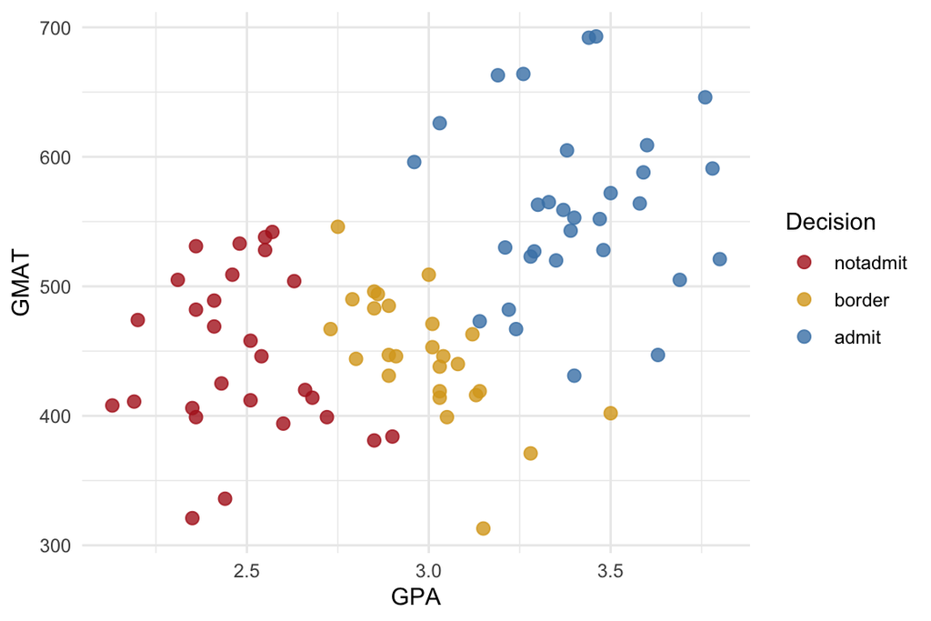

Figure 2.1: GPA vs GMAT coloured by admission decision

```r
ggplot(admission, aes(x = GPA, y = GMAT, colour = decision)) +
  geom_point(size = 2.5, alpha = 0.8) +
  scale_colour_manual(values = c(notadmit = "firebrick",
                                 border   = "goldenrod",
                                 admit    = "steelblue")) +
  labs(x = "GPA", y = "GMAT", colour = "Decision") +
  theme_minimal()
```

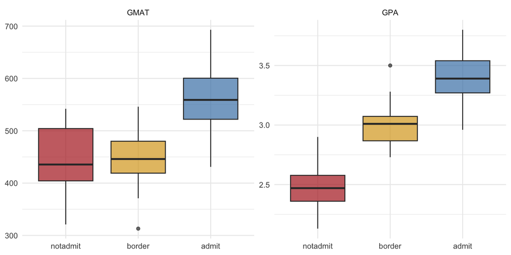

Figure 2.2: Distribution of GPA and GMAT by decision

```r
admission %>%
  pivot_longer(c(GPA, GMAT), names_to = "variable", values_to = "value") %>%
  ggplot(aes(x = decision, y = value, fill = decision)) +
  geom_boxplot(alpha = 0.7, show.legend = FALSE) +
  facet_wrap(~ variable, scales = "free_y") +
  scale_fill_manual(values = c(notadmit = "firebrick",
                               border   = "goldenrod",
                               admit    = "steelblue")) +
  labs(x = NULL, y = NULL) +
  theme_minimal()
```

Both GPA and GMAT separate the groups reasonably well, though with overlap — especially for the border cases.

## 2.1 Binary simplification

We begin with the simpler binary problem: `admit` vs. everything else (merging `border` and `notadmit` into a single negative class). We also create a numeric 0/1 coding, which will be useful shortly.

```r
admission <- admission %>%
  mutate(
    decision2 = factor(ifelse(decision == "admit", "admit", "notadmit"),
                       levels = c("notadmit", "admit")),
    y = as.integer(decision2) - 1L   # 0 = notadmit, 1 = admit
  )
```

# 3 Why not linear regression?

Since $y$ is coded as 0/1, one might try a linear model. Let us see what happens when we fit $y$ on GMAT.

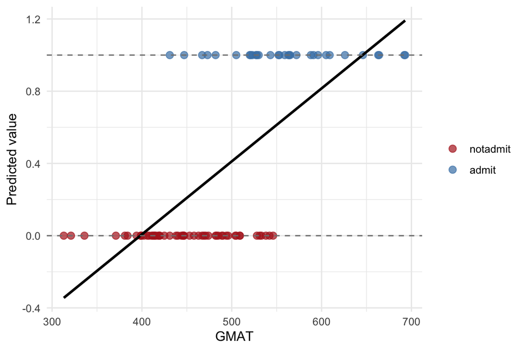

Figure 3.1: Linear regression on a 0/1 response: predictions go outside [0,1]

```r
fit_lm <- lm(y ~ GMAT, data = admission)

gmat_grid <- data.frame(GMAT = seq(min(admission$GMAT),
                                   max(admission$GMAT), length.out = 200))
gmat_grid$pred <- predict(fit_lm, newdata = gmat_grid)

ggplot(admission, aes(x = GMAT, y = y)) +
  geom_point(aes(colour = decision2), size = 2.5, alpha = 0.7) +
  geom_line(data = gmat_grid, aes(y = pred), colour = "black", linewidth = 1) +
  geom_hline(yintercept = c(0, 1), linetype = "dashed", colour = "grey50") +
  scale_colour_manual(values = c(notadmit = "firebrick", admit = "steelblue")) +
  labs(x = "GMAT", y = "Predicted value", colour = NULL) +
  theme_minimal()
```

```r
pred_lm <- predict(fit_lm,
  newdata = data.frame(GMAT = c(min(admission$GMAT), max(admission$GMAT))))
cat("Prediction at GMAT =", min(admission$GMAT), ":", round(pred_lm[1], 3), "\n")
```

```
## Prediction at GMAT = 313 : -0.344
```

```r
cat("Prediction at GMAT =", max(admission$GMAT), ":", round(pred_lm[2], 3), "\n")
```

```
## Prediction at GMAT = 693 : 1.191
```

Both predictions are outside $[0,1]$, which makes no sense as probabilities. The problem is structural: a linear function on $\mathbb{R}$ cannot be constrained to stay in $[0,1]$.

# 4 The logistic model

## 4.1 The sigmoid function

We need a function that maps any real number to the interval $(0,1)$. The standard choice is the **logistic (sigmoid) function**:

$$\sigma(z) = \frac{e^z}{1 + e^z} = \frac{1}{1 + e^{-z}}$$

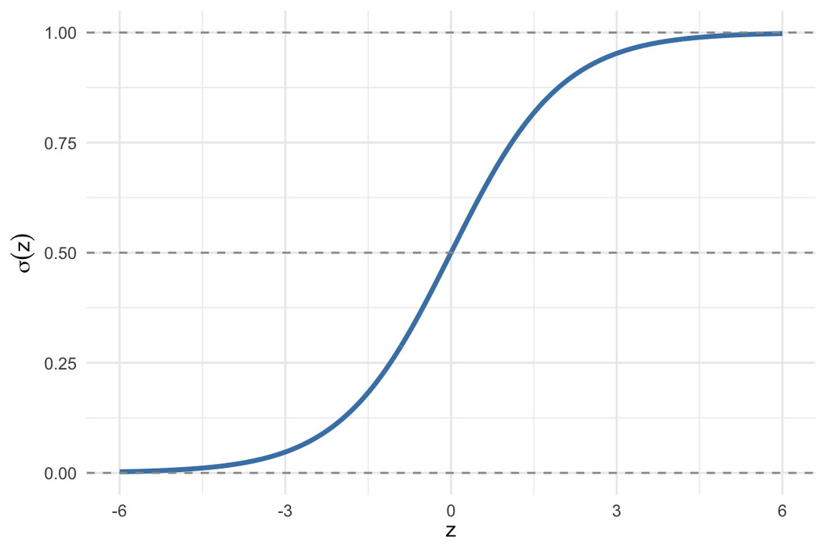

Figure 4.1: The sigmoid function maps any real number to (0, 1)

```r
z <- seq(-6, 6, length.out = 300)
ggplot(data.frame(z = z, sigma = 1 / (1 + exp(-z))), aes(x = z, y = sigma)) +
  geom_line(colour = "steelblue", linewidth = 1.2) +
  geom_hline(yintercept = c(0, 0.5, 1), linetype = "dashed", colour = "grey60") +
  labs(x = expression(z), y = expression(sigma(z))) +
  theme_minimal()
```

## 4.2 The model

The logistic model predicts the probability of $Y = 1$ given a predictor $X$ as:

$$p(X) = P(Y = 1 \mid X) = \frac{e^{\beta_0 + \beta_1 X}}{1 + e^{\beta_0 + \beta_1 X}}$$

A simple rearrangement gives the **log-odds** (or **logit**):

$$\log \frac{p(X)}{1 - p(X)} = \beta_0 + \beta_1 X$$

The log-odds are linear in $X$, even though the probability $p(X)$ is not. The parameters $\beta_0$ and $\beta_1$ are estimated by **maximum likelihood** — there is no closed-form solution, unlike OLS.

> **Interpreting $\beta_1$:** a one-unit increase in $X$ multiplies the **odds** by $e^{\beta_1}$. If $\beta_1 > 0$, higher $X$ means higher probability of $Y = 1$; if $\beta_1 < 0$, lower.

# 5 Fitting the model in R

Logistic regression is a special case of a **Generalised Linear Model (GLM)**, fitted with `glm(..., family = binomial)`. The default link is the logit.

```r
fit_gmat <- glm(y ~ GMAT, data = admission, family = binomial)
summary(fit_gmat)
```

```
##
## Call:
## glm(formula = y ~ GMAT, family = binomial, data = admission)
##
## Coefficients:
##               Estimate Std. Error z value Pr(>|z|)
## (Intercept) -17.397141   3.758928  -4.628 3.69e-06 ***
## GMAT          0.033609   0.007386   4.551 5.35e-06 ***
## ---
## Signif. codes:  0 '***' 0.001 '**' 0.01 '*' 0.05 '.' 0.1 ' ' 1
##
## (Dispersion parameter for binomial family taken to be 1)
##
##     Null deviance: 111.533  on 84  degrees of freedom
## Residual deviance:  60.106  on 83  degrees of freedom
## AIC: 64.106
##
## Number of Fisher Scoring iterations: 6
```

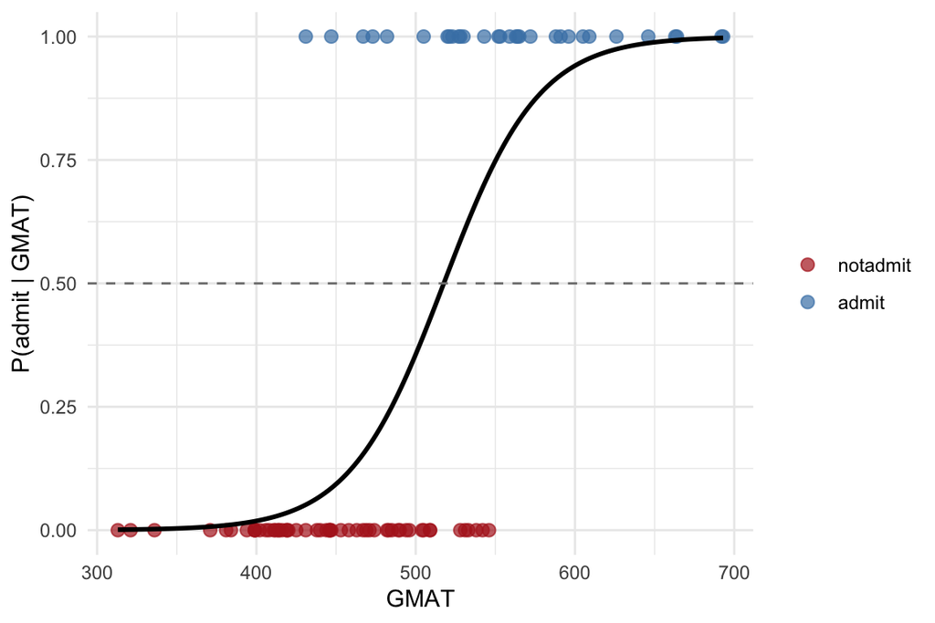

Figure 5.1: Logistic regression of admission probability on GMAT

```r
gmat_grid$prob <- predict(fit_gmat, newdata = gmat_grid, type = "response")

ggplot(admission, aes(x = GMAT, y = y)) +
  geom_point(aes(colour = decision2), size = 2.5, alpha = 0.7) +
  geom_line(data = gmat_grid, aes(y = prob), colour = "black", linewidth = 1) +
  geom_hline(yintercept = 0.5, linetype = "dashed", colour = "grey50") +
  scale_colour_manual(values = c(notadmit = "firebrick", admit = "steelblue")) +
  labs(x = "GMAT", y = "P(admit | GMAT)", colour = NULL) +
  theme_minimal()
```

The slope is positive ($\hat\beta_1 = 0.0336$): a higher GMAT score increases the probability of admission. Each additional GMAT point multiplies the odds by $e^{0.0336} \approx 1.0342$.

## 5.1 Predictions

`predict(..., type = "response")` returns probabilities directly.

```r
p_ext <- predict(fit_gmat,
  newdata = data.frame(GMAT = c(min(admission$GMAT), max(admission$GMAT))),
  type = "response")
cat("P(admit | GMAT =", min(admission$GMAT), ") =",
    round(p_ext[1] * 100, 2), "%\n")
```

```
## P(admit | GMAT = 313 ) = 0.1 %
```

```r
cat("P(admit | GMAT =", max(admission$GMAT), ") =",
    round(p_ext[2] * 100, 2), "%\n")
```

```
## P(admit | GMAT = 693 ) = 99.73 %
```

Predictions are now sensible probabilities, unlike the linear model above.

## 5.2 Verifying the formula by hand

It is instructive to verify that `predict` is indeed applying the formula. For a candidate with GMAT equal to the minimum value in the dataset, the fitted log-odds are $\hat\beta_0 + \hat\beta_1 \times 313$, so the probability is:

```r
b0 <- coef(fit_gmat)[1]
b1 <- coef(fit_gmat)[2]

for (gmat_val in c(min(admission$GMAT), max(admission$GMAT))) {
  log_odds <- b0 + b1 * gmat_val
  p_manual <- exp(log_odds) / (1 + exp(log_odds))
  cat("GMAT =", gmat_val,
      " | log-odds =", round(log_odds, 4),
      " | p =", round(p_manual * 100, 4), "%\n")
}
```

```
## GMAT = 313  | log-odds = -6.8775  | p = 0.103 %
## GMAT = 693  | log-odds = 5.8939  | p = 99.7251 %
```

These match the `predict` output exactly, confirming that the model is simply plugging the linear predictor into the sigmoid function.

# 6 Classification: the threshold

The logistic model outputs a **probability**, not a class. To obtain a class prediction we apply a **threshold** $t$: predict `admit` if $\hat p > t$, otherwise `notadmit`. The default $t = 0.5$ is just a convention — the right threshold depends on the costs of each type of error.

## 6.1 The confusion matrix

For $t = 0.5$:

```r
admission$prob  <- predict(fit_gmat, type = "response")
admission$pred  <- factor(ifelse(admission$prob > 0.5, "admit", "notadmit"),
                          levels = c("notadmit", "admit"))

cm <- table(Real = admission$decision2, Predicted = admission$pred)
cm
```

```
##           Predicted
## Real       notadmit admit
##   notadmit       48     6
##   admit           6    25
```

The four cells of the confusion matrix are:

|  | Predicted notadmit | Predicted admit |
| --- | --- | --- |
| **Real notadmit** | True Negative (TN) | False Positive (FP) |
| **Real admit** | False Negative (FN) | True Positive (TP) |

From these we derive the main metrics:

- **Accuracy** = (TP + TN) / $n$ — overall fraction correct.
- **Sensitivity** (TPR, Recall) = TP / (TP + FN) — fraction of real positives detected.
- **Specificity** (TNR) = TN / (TN + FP) — fraction of real negatives correctly identified.
- **Precision** (PPV) = TP / (TP + FP) — fraction of predicted positives that are real.

```r
confusion_metrics <- function(cm) {
  TN <- cm[1,1]; FP <- cm[1,2]; FN <- cm[2,1]; TP <- cm[2,2]
  n  <- sum(cm)
  data.frame(
    Accuracy    = round((TP + TN) / n, 3),
    Sensitivity = round(TP / (TP + FN), 3),
    Specificity = round(TN / (TN + FP), 3),
    Precision   = round(TP / (TP + FP), 3)
  )
}

confusion_metrics(cm)
```

| Accuracy | Sensitivity | Specificity | Precision |
| --- | --- | --- | --- |
| 0.859 | 0.806 | 0.889 | 0.806 |

## 6.2 Changing the threshold

Raising the threshold makes the model more conservative: fewer admits are predicted, so sensitivity drops and specificity rises. Lowering it does the opposite.

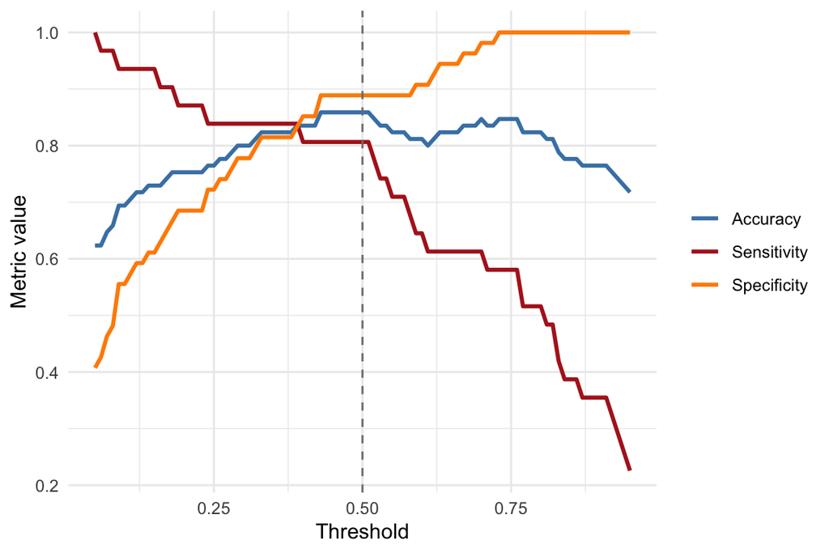

Figure 6.1: Classification metrics as a function of the threshold

```r
thresholds <- seq(0.05, 0.95, by = 0.01)

metrics_df <- lapply(thresholds, function(t) {
  pred <- factor(ifelse(admission$prob > t, "admit", "notadmit"),
                 levels = c("notadmit", "admit"))
  cm_t <- table(Real = admission$decision2, Predicted = pred)
  if (nrow(cm_t) < 2 || ncol(cm_t) < 2) return(NULL)
  TN <- cm_t[1,1]; FP <- cm_t[1,2]; FN <- cm_t[2,1]; TP <- cm_t[2,2]
  n  <- sum(cm_t)
  data.frame(threshold   = t,
             Accuracy    = (TP + TN) / n,
             Sensitivity = TP / (TP + FN),
             Specificity = TN / (TN + FP))
}) %>% bind_rows()

metrics_df %>%
  pivot_longer(-threshold, names_to = "Metric", values_to = "Value") %>%
  ggplot(aes(x = threshold, y = Value, colour = Metric)) +
  geom_line(linewidth = 1) +
  geom_vline(xintercept = 0.5, linetype = "dashed", colour = "grey50") +
  scale_colour_manual(values = c(Accuracy    = "steelblue",
                                 Sensitivity = "firebrick",
                                 Specificity = "darkorange")) +
  labs(x = "Threshold", y = "Metric value", colour = NULL) +
  theme_minimal()
```

> There is always a trade-off: you cannot simultaneously maximise sensitivity and specificity. The right choice depends on the problem — in medical screening you may prefer high sensitivity (miss fewer true cases) even at the cost of more false alarms.

# 7 The ROC curve and AUC

Instead of committing to one threshold, the **Receiver Operating Characteristic (ROC)** curve traces the sensitivity–specificity trade-off across *all* possible thresholds. It is the standard way to evaluate a binary classifier independently of any particular threshold.

The **Area Under the Curve (AUC)** summarises the ROC in a single number: AUC = 1 is a perfect classifier, AUC = 0.5 is no better than random (the diagonal), and AUC < 0.5 means the model is systematically wrong.

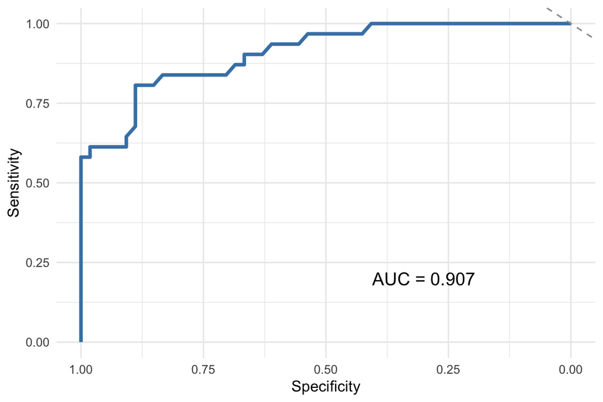

Figure 7.1: ROC curve for the logistic model with GMAT only

```r
roc_gmat <- roc(admission$y, admission$prob, quiet = TRUE)

ggroc(roc_gmat, colour = "steelblue", linewidth = 1.2) +
  geom_abline(slope = -1, intercept = 1, linetype = "dashed", colour = "grey60") +
  annotate("text", x = 0.3, y = 0.2,
           label = paste0("AUC = ", round(auc(roc_gmat), 3)), size = 4.5) +
  labs(x = "Specificity", y = "Sensitivity") +
  theme_minimal()
```

Note: `ggroc` from `pROC` plots specificity on the x-axis decreasing from left to right, so the random-classifier diagonal runs from top-left to bottom-right.

## 7.1 Optimal threshold from the ROC curve

```r
coords(roc_gmat, "best",
       ret = c("threshold", "sensitivity", "specificity"))
```

| threshold | sensitivity | specificity |
| --- | --- | --- |
| 0.4739174 | 0.8064516 | 0.8888889 |

# 8 Two predictors: GPA and GMAT

Adding GPA alongside GMAT gives a more realistic model.

```r
fit_two <- glm(y ~ GPA + GMAT, data = admission, family = binomial)
summary(fit_two)
```

```
##
## Call:
## glm(formula = y ~ GPA + GMAT, family = binomial, data = admission)
##
## Coefficients:
##              Estimate Std. Error z value Pr(>|z|)
## (Intercept) -223.6349   162.5991  -1.375    0.169
## GPA           41.2864    29.5065   1.399    0.162
## GMAT           0.1965     0.1473   1.334    0.182
##
## (Dispersion parameter for binomial family taken to be 1)
##
##     Null deviance: 111.5332  on 84  degrees of freedom
## Residual deviance:   6.5035  on 82  degrees of freedom
## AIC: 12.504
##
## Number of Fisher Scoring iterations: 12
```

## 8.1 Decision boundary

With two numeric predictors the decision boundary — the set of points where $\hat p = 0.5$ — is a straight line in the predictor space. At threshold $t = 0.5$ the logit equals 0, giving:

$$\text{GMAT} = -\frac{\hat\beta_0 + \hat\beta_1 \cdot \text{GPA}}{\hat\beta_2}$$

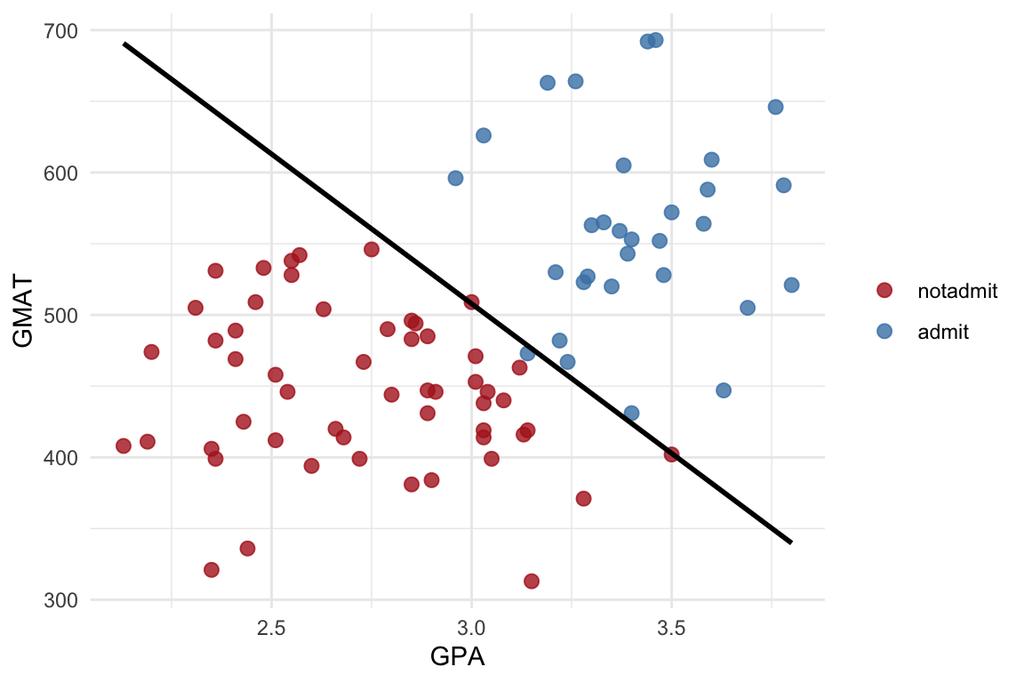

Figure 8.1: Decision boundary of the two-predictor logistic model at threshold 0.5

```r
b <- coef(fit_two)
gpa_seq  <- seq(min(admission$GPA), max(admission$GPA), length.out = 200)
boundary <- data.frame(GPA  = gpa_seq,
                       GMAT = -(b[1] + b[2] * gpa_seq) / b[3])

ggplot(admission, aes(x = GPA, y = GMAT, colour = decision2)) +
  geom_point(size = 2.5, alpha = 0.8) +
  geom_line(data = boundary, aes(x = GPA, y = GMAT),
            colour = "black", linewidth = 1, inherit.aes = FALSE) +
  scale_colour_manual(values = c(notadmit = "firebrick", admit = "steelblue")) +
  labs(colour = NULL) +
  theme_minimal()
```

## 8.2 Comparing the two models with ROC

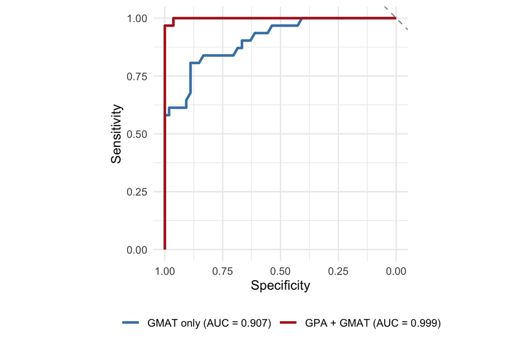

Figure 8.2: ROC curves: GMAT only vs GPA + GMAT

```r
admission$prob_two <- predict(fit_two, type = "response")
roc_two <- roc(admission$y, admission$prob_two, quiet = TRUE)

roc_list <- list(
  "GMAT only"  = roc_gmat,
  "GPA + GMAT" = roc_two
)

ggroc(roc_list, linewidth = 1) +
  geom_abline(slope = -1, intercept = 1, linetype = "dashed", colour = "grey60") +
  scale_colour_manual(
    values = c("GMAT only" = "steelblue", "GPA + GMAT" = "firebrick"),
    labels = c(paste0("GMAT only (AUC = ",  round(auc(roc_gmat), 3), ")"),
               paste0("GPA + GMAT (AUC = ", round(auc(roc_two),  3), ")"))
  ) +
  labs(x = "Specificity", y = "Sensitivity", colour = NULL) +
  coord_fixed() +
  theme_minimal() +
  theme(legend.position = "bottom")
```

Adding GPA increases the AUC from 0.907 to 0.999, a meaningful improvement.

# 9 Pseudo $R^2$

Unlike linear regression, logistic regression has no natural $R^2$. The most common substitute is **McFadden’s pseudo $R^2$**:

$$R^2_{\text{McFadden}} = 1 - \frac{\text{Residual deviance}}{\text{Null deviance}}$$

It equals 0 for a model with no predictors and approaches 1 as the fit becomes perfect. Values between 0.2 and 0.4 are generally considered good.

```r
pseudo_r2 <- function(fit) 1 - fit$deviance / fit$null.deviance

data.frame(
  Model    = c("GMAT only", "GPA + GMAT"),
  Pseudo_R2 = round(c(pseudo_r2(fit_gmat), pseudo_r2(fit_two)), 4)
)
```

| Model | Pseudo_R2 |
| --- | --- |
| GMAT only | 0.4611 |
| GPA + GMAT | 0.9417 |

# 10 The probit model

The **probit model** replaces the logistic sigmoid with the normal CDF $\Phi$:

$$p(X) = \Phi(\beta_0 + \beta_1 X)$$

In R only the `link` argument changes:

```r
fit_probit <- glm(y ~ GMAT, data = admission, family = binomial(link = "probit"))
summary(fit_probit)
```

```
##
## Call:
## glm(formula = y ~ GMAT, family = binomial(link = "probit"), data = admission)
##
## Coefficients:
##              Estimate Std. Error z value Pr(>|z|)
## (Intercept) -9.963885   1.927869  -5.168 2.36e-07 ***
## GMAT         0.019300   0.003818   5.055 4.29e-07 ***
## ---
## Signif. codes:  0 '***' 0.001 '**' 0.01 '*' 0.05 '.' 0.1 ' ' 1
##
## (Dispersion parameter for binomial family taken to be 1)
##
##     Null deviance: 111.533  on 84  degrees of freedom
## Residual deviance:  59.945  on 83  degrees of freedom
## AIC: 63.945
##
## Number of Fisher Scoring iterations: 6
```

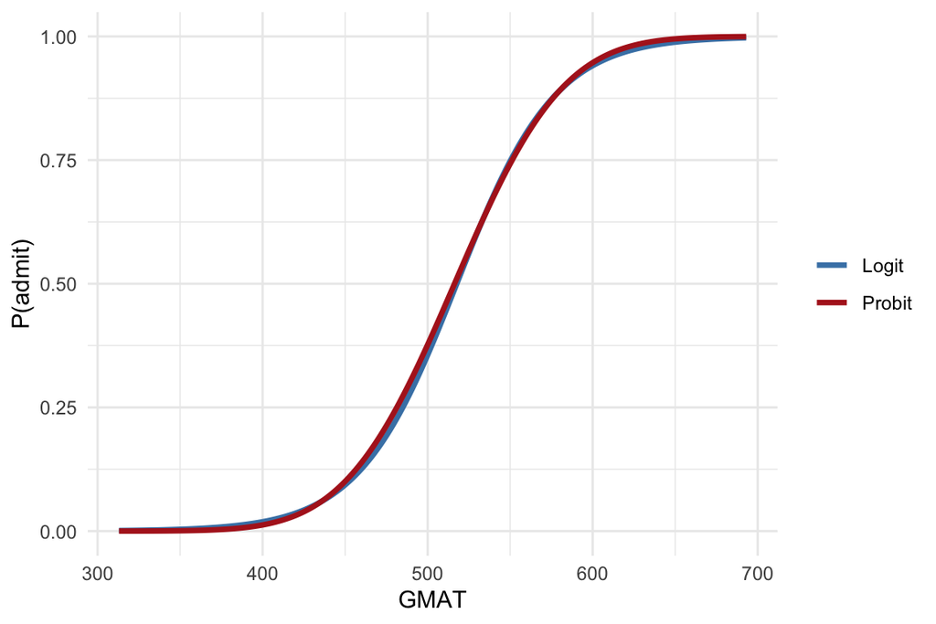

Figure 10.1: Logistic vs probit fitted curves — virtually identical in practice

```r
gmat_grid$prob_probit <- predict(fit_probit, newdata = gmat_grid, type = "response")

gmat_grid %>%
  pivot_longer(c(prob, prob_probit), names_to = "model", values_to = "p") %>%
  mutate(model = recode(model, prob = "Logit", prob_probit = "Probit")) %>%
  ggplot(aes(x = GMAT, y = p, colour = model)) +
  geom_line(linewidth = 1.2) +
  scale_colour_manual(values = c(Logit = "steelblue", Probit = "firebrick")) +
  labs(x = "GMAT", y = "P(admit)", colour = NULL) +
  theme_minimal()
```

The two curves are nearly indistinguishable. Logit is more common because $e^{\hat\beta}$ has a direct interpretation as an odds ratio; probit is sometimes preferred in econometrics.

## 10.1 Verifying the probit formula by hand

Just as we did for the logit, we can verify that `predict` is applying $\Phi(\hat\beta_0 + \hat\beta_1 X)$ directly — using `pnorm` for the normal CDF:

```r
g0 <- coef(fit_probit)[1]
g1 <- coef(fit_probit)[2]

for (gmat_val in c(min(admission$GMAT), max(admission$GMAT))) {
  p_manual <- pnorm(g0 + g1 * gmat_val)
  cat("GMAT =", gmat_val,
      " | p =", round(p_manual * 100, 4), "%\n")
}
```

```
## GMAT = 313  | p = 0.0044 %
## GMAT = 693  | p = 99.9676 %
```

The results match `predict(..., type = "response")`, confirming the formula.

# 11 Coding note: factor vs numeric response

A natural alternative to coding $y$ as 0/1 is passing a factor directly to `glm`. This works, but R’s default factor ordering (alphabetical) may predict the wrong class.

```r
# alphabetical ordering: "admit" < "notadmit", so R models P(notadmit)
contrasts(factor(admission$decision2))
```

```
##          admit
## notadmit     0
## admit        1
```

```r
fit_factor <- glm(
  factor(decision2, levels = c("notadmit", "admit")) ~ GMAT,
  data = admission, family = binomial
)
all.equal(coef(fit_gmat), coef(fit_factor), check.names = FALSE)
```

```
## [1] TRUE
```

Always check `contrasts()` when using a factor response; a sign flip means you are predicting the wrong class.

# 12 Multinomial logistic regression

When the response has $K > 2$ classes we use **multinomial logistic regression**, fitted with `multinom()` from the `nnet` package. One class is the **reference** and the model estimates $K - 1$ sets of coefficients, each giving the log-odds of that class relative to the reference.

Here we use the original three-class response: `admit`, `border`, `notadmit`.

```r
fit_multi <- multinom(decision ~ GPA + GMAT, data = admission)
```

```r
summary(fit_multi)
```

```
## Call:
## multinom(formula = decision ~ GPA + GMAT, data = admission)
##
## Coefficients:
##        (Intercept)      GPA       GMAT
## border   -134.1421 36.96973 0.07002442
## admit    -260.4073 60.70567 0.17800171
##
## Std. Errors:
##        (Intercept)      GPA       GMAT
## border   0.5895009 1.619554 0.01084123
## admit    0.4168283 2.337048 0.01590936
##
## Residual Deviance: 13.1286
## AIC: 25.1286
```

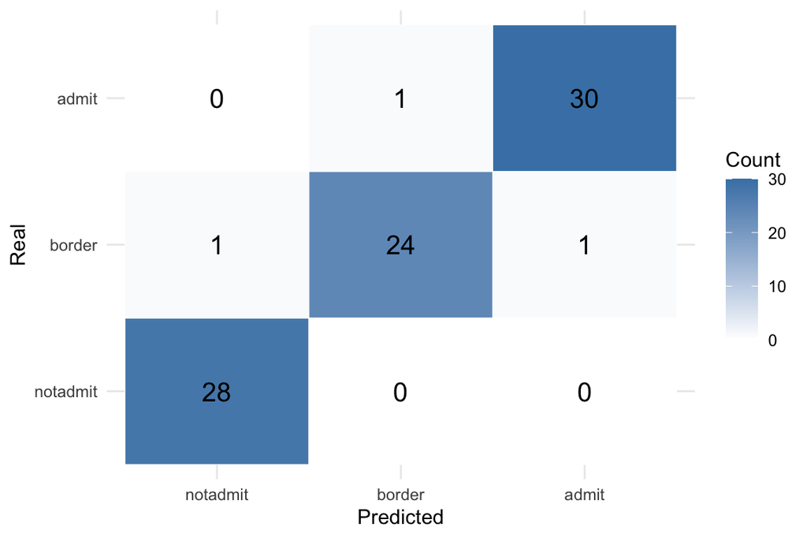

Figure 12.1: Confusion matrix for the multinomial model

```r
pred_multi <- predict(fit_multi)
cm_multi   <- table(Real = admission$decision, Predicted = pred_multi)

as.data.frame(cm_multi) %>%
  ggplot(aes(x = Predicted, y = Real, fill = Freq)) +
  geom_tile(colour = "white") +
  geom_text(aes(label = Freq), size = 5) +
  scale_fill_gradient(low = "white", high = "steelblue") +
  labs(fill = "Count") +
  theme_minimal()
```

```r
cat("Overall accuracy:",
    round(sum(diag(cm_multi)) / sum(cm_multi), 3), "\n")
```

```
## Overall accuracy: 0.965
```

# 13 Summary

| Concept | Function | Notes |
| --- | --- | --- |
| Logistic model | `glm(..., family = binomial)` | default link: logit |
| Probit model | `glm(..., family = binomial(link = "probit"))` | link: $\Phi$ |
| Predicted probabilities | `predict(fit, type = "response")` | always specify `type` |
| Confusion matrix | `table(real, predicted)` | depends on chosen threshold |
| ROC / AUC | `roc()`, `auc()` from `pROC` | threshold-independent evaluation |
| Pseudo $R^2$ | `1 - deviance / null.deviance` | McFadden; 0.2–0.4 is good |
| Multinomial | `multinom()` from `nnet` | $K-1$ sets of coefficients |
| Factor response | set levels explicitly | check `contrasts()` to avoid sign flip |

Key takeaways: logistic regression outputs **probabilities**; converting to a class requires choosing a **threshold**, which is a real modelling decision. The **ROC curve** and **AUC** let you evaluate and compare models without committing to a single threshold.